# distfromq

# Introduction

The `distfromq` package provides functions for constructing an approximation to a probability distribution from a finite set of quantiles of the distribution. The package provides four main functions:

1. `make_p_fn` returns a function that is analogous to `pnorm`, and can be used to evaluate the approximated cumulative distribution function (CDF).
2. `make_d_fn` returns a function that is analogous to `dnorm`, and can be used to evaluate the approximated probability density function (PDF).
3. `make_q_fn` returns a function that is analogous to `qnorm`, and can be used to evaluate the approximated quantile function (QF), i.e., the inverse CDF.
4. `make_r_fn` returns a function that is analogous to `rnorm`, and can be used to simulate a pseudo-random sample from the approximated distribution.

All four functions take a set of probability levels (`ps`) and the corresponding quantiles (`qs`) of the distribution to be approximated as inputs, as well as arguments specifying the methods for interpolating those quantiles to estimate the interior of the distribution, and for extrapolating into the tails of the distribution using a specified parametric family.

The next section of the vignette describes the methods that are used for approximating the distribution, and the following section gives examples.

# Methods description

Suppose that we have a collection of pairs $(q_k, \tau_k)$, $k = 1, \ldots, K$, where for each $k$, $\tau_k = F(q_k)$ or $q_k = F^{-1}(\tau_k)$ for some distribution with CDF $F$ and quantile function $F^{-1}$. We allow for the distribution to have regions with no density or with discrete point masses, corresponding to regions where $F$ is flat or has a vertical step. In these instances, the points $(q_k, \tau_k)$ may fall within the flat region or partway up the vertical step, as will be illustrated below. Our goal is to reconstruct an estimate of $F$, the corresponding PDF $f$ (if the distribution is continuous), and the QF $F^{-1}$, as well as a method for sampling from the distribution.

Our approach first splits the provided quantiles into a discrete part of the distribution and a continuous part. Then, for the continuous part it takes different strategies for interpolating on the interior of the provided quantiles and for extrapolating into the tails. We outline these procedures briefly here and give more detail below:

1. Split into discrete and continuous parts.
   - Discrete components of the distribution (i.e., point masses) are identified in the following cases:
     - there are repeated quantiles across different probability levels (i.e., $q_k \approx q_{k'}$ for some indices $k \neq k'$). In this case, we say that there is a point mass at the value(s) of $q$ that was (were) repeated. The discrete distribution assigns probability to each such point $q$ corresponding to $\max(\{\tau_{k}: q_k \approx q\}) - \min(\{\tau_{k}: q_k \approx q\})$. The parameter `dup_tol` controls identification of quantiles that are “close enough” to identify a point mass.
     - the parametric family to be used for extrapolation into the tails is a lognormal distribution and there are one or more quantiles that are approximately 0. In this case, we say that there is a point mass at zero, with probability equal to $\max(\{\tau_{k}: q_k \approx 0\})$. The parameter `zero_tol` controls identification of quantiles that are “close enough to zero” to identify a point mass.
   - The result of this step is a collection of locations of discrete point masses and their associated probabilities, and a set of quantiles and associated probability levels that can be used for estimating the continuous part of the distribution in the following step.
2. Estimate the continuous part of the distribution.
   - On the interior of the quantiles for the continuous part of the distribution, we estimate the continuous component using a monotonic spline that interpolates the quantiles.
   - We approximate the tails with a distribution in a specified location-scale family.

To estimate the quantile function (QF), we invert the estimate of the CDF. To estimate the probability density function (PDF), we use the derivative of the spline-based approximation to the CDF if there are no discrete components. This function does not support estimation of a density function if the distribution has any discrete components.

## CDF estimation in the tails

We estimate the distribution for the left and right tails separately, assuming that they come from a specified location-scale family. The distributional family is assumed to be the same in each tail, but the location and scale parameters may differ in the left and right tails. Setting notation, suppose that $Y = a + b \cdot Z$ where the random variable $Z$ has a specified distribution. Recall that at the probability level $\tau$, a quantile of $Y$ can be calculated in terms of the corresponding quantile of $Z$ via $F_Y^{-1}(\tau) = a + b \cdot F_Z^{-1}(\tau)$. Using the quantiles at two probability levels $\tau_i$ and $\tau_j$, we can calculate the value of $b$ using

$$\begin{align*}
\frac{F_Y^{-1}(\tau_i) - F_Y^{-1}(\tau_j)}{F_Z^{-1}(\tau_i) - F_Z^{-1}(\tau_j)} &= \frac{a + b \cdot F_Z^{-1}(\tau_i) - (a + b \cdot F_Z^{-1}(\tau_j))} {F_Z^{-1}(\tau_i) - F_Z^{-1}(\tau_j)} \\
&= b \cdot \frac{F_Z^{-1}(\tau_i) - F_Z^{-1}(\tau_j)}{F_Z^{-1}(\tau_i) - F_Z^{-1}(\tau_j)} \\
&= b
\end{align*}$$

Similarly, we can calculate the value of $a$ as

$$F_Y^{-1}(\tau_i) - b \cdot F_Z^{-1}(\tau_i) = a + b \cdot F_Z^{-1}(\tau_i) - b \cdot F_Z^{-1}(\tau_i) = a$$

In the above expressions, we use the two smallest quantiles when estimating the lower tail and the two largest quantiles when estimating the upper tail. With these choices, by construction the lower tail integrates to $\tau_1$ on the interval $(-\infty, q_1]$ and the upper tail integrates to $1 - \tau_K$ on the interval $[q_K, \infty)$.

As an alternative, we also allow for the use of a log-normal distribution for extrapolation into the tails. The parameters of the log-normal distribution are estimated by applying the approach outlined above to the logarithms of the quantiles.

## Estimation of the QF and PDF, and random deviate generation

To estimate the QF, we invert the CDF estimate, allowing for jumps in regions where the CDF is flat. As noted above, this can be numerically unstable if `n_grid = NULL` (thus using the spline fit directly), so it is recommended that the `n_grid` parameter be set to an integer if QF estimates are desired.

To estimate the PDF in instances where the CDF estimate corresponds to a continuous distribution, we differentiate the CDF estimate. If the stage 2 CDF estimate is used, this yields a “histogram density” estimate, which is discontinuous and piecewise constant. If this presents a challenge, the grid size can be increased or the stage 1 CDF estimate used instead.

Random deviates are obtained by sampling $U \sim \text{Unif}(0,1)$ and then evaluating the approximated quantile function: $Y = F_Y^{-1}(U)$.

# Illustration of package functionality

We illustrate the package functionality with a series of four examples. The first example is a setting where the distribution is for a continuous random variable with a defined probability density funciton. The remaining examples illustrate the behavior of the functions in settings where the provided quantiles are the same at multiple probability levels or a lognormal distribution is used for tail extrapolation and there is at least one quantile at zero, indicating that there is some discrete component to the distribution.

```r
library(distfromq)
library(ggplot2)
library(dplyr)
```

## Example 1

In our first example, we work with quantiles from the distribution $Y \sim \text{log normal}(4, 0.5)$. We compare this predictive distribution with three approximations of it that are derived from the quantiles using different assumptions for the tail behavior:

1. The first assumes a log-normal distribution for the tails. This method should reconstruct the true distribution.
2. The second assumes a normal distribution for the tails. This method has a mismatch in the support of the lower tail (including values less than 0), and has a thinner upper tail than the log-normal.
3. The third assumes a Cauchy distribution for the tails. This method has a mismatch in the support of the lower tail (including values less than 0), and has a heavier upper tail than the log-normal.

```r
quantile_probs <- seq(from = 0.1, to = 0.9, by = 0.1)

meanlog <- 4.0
sdlog <- 0.5
q_lognormal <- qlnorm(quantile_probs, meanlog = meanlog, sdlog = sdlog)
```

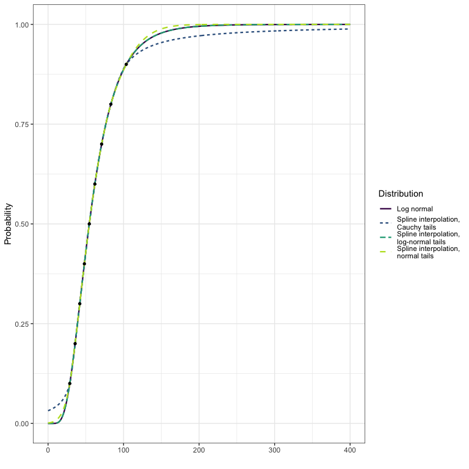

```r
x <- seq(from = 0.0, to = 400.0, length = 501)
cdf_lognormal <- plnorm(x, meanlog = meanlog, sdlog = sdlog)

p_lognormal_approx <- make_p_fn(ps = quantile_probs,
                                qs = q_lognormal,
                                tail_dist = "lnorm")
cdf_lognormal_approx <- p_lognormal_approx(x)

# note that `tail_dist = "norm"` is the default; we specify it here for clarity
p_normal_approx <- make_p_fn(ps = quantile_probs,
                             qs = q_lognormal,
                             tail_dist = "norm")
cdf_normal_approx <- p_normal_approx(x)

p_cauchy_approx <- make_p_fn(ps = quantile_probs,
                             qs = q_lognormal,
                             tail_dist = "cauchy")
cdf_cauchy_approx <- p_cauchy_approx(x)

dplyr::bind_rows(
    data.frame(
        x = x,
        y = cdf_lognormal,
        dist = "Log normal"
    ),
    data.frame(
        x = x,
        y = cdf_lognormal_approx,
        dist = "Spline interpolation,\nlog-normal tails"
    ),
    data.frame(
        x = x,
        y = cdf_normal_approx,
        dist = "Spline interpolation,\nnormal tails"
    ),
    data.frame(
        x = x,
        y = cdf_cauchy_approx,
        dist = "Spline interpolation,\nCauchy tails"
    )
) %>%
    ggplot() +
        geom_line(
            mapping = aes(x = x, y = y, color = dist, linetype = dist),
            size = 0.8) +
        geom_point(
            data = data.frame(q = q_lognormal, p = quantile_probs),
            mapping = aes(x = q, y = p),
            size = 1.2
        ) +
        scale_color_viridis_d(
            "Distribution",
            end = 0.9
        ) +
        scale_linetype_discrete("Distribution") +
        ylab("Probability") +
        xlab("") +
        theme_bw()
```

The following illustrates differences in the density estimates.

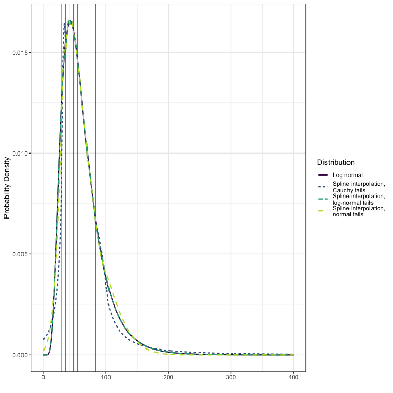

```r
d_lognormal_approx <- make_d_fn(ps = quantile_probs,
                                qs = q_lognormal,
                                tail_dist = "lnorm")

d_normal_approx <- make_d_fn(ps = quantile_probs,
                             qs = q_lognormal,
                             tail_dist = "norm")

d_cauchy_approx <- make_d_fn(ps = quantile_probs,
                             qs = q_lognormal,
                             tail_dist = "cauchy")

pdf_lognormal <- dlnorm(x, meanlog = meanlog, sdlog = sdlog)
pdf_lognormal_approx <- d_lognormal_approx(x)
pdf_normal_approx <- d_normal_approx(x)
pdf_cauchy_approx <- d_cauchy_approx(x)

dplyr::bind_rows(
    data.frame(
        x = x,
        y = pdf_lognormal,
        dist = "Log normal"
    ),
    data.frame(
        x = x,
        y = pdf_lognormal_approx,
        dist = "Spline interpolation,\nlog-normal tails"
    ),
    data.frame(
        x = x,
        y = pdf_normal_approx,
        dist = "Spline interpolation,\nnormal tails"
    ),
    data.frame(
        x = x,
        y = pdf_cauchy_approx,
        dist = "Spline interpolation,\nCauchy tails"
    )
) %>%
    ggplot() +
        geom_vline(
            data = data.frame(q = q_lognormal),
            mapping = aes(xintercept = q),
            size = 0.2
        ) +
        geom_line(
            mapping = aes(x = x, y = y, color = dist, linetype = dist),
            size = 0.8) +
        scale_color_viridis_d(
            "Distribution",
            end = 0.9
        ) +
        scale_linetype_discrete("Distribution") +
        ylab("Probability Density") +
        xlab("") +
        theme_bw()
```

We emphasize that the density is a step function. We illustrate this by setting the `n_grid` parameter to the artificially low value of 1:

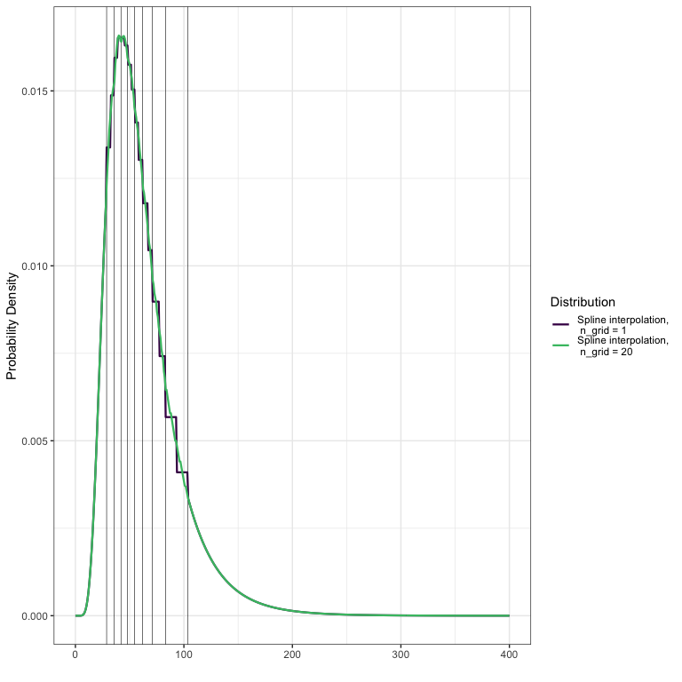

```r
d_lognormal_approx_n_grid_1 <- make_d_fn(ps = quantile_probs,
                                qs = q_lognormal,
                                tail_dist = "lnorm",
                                interior_args = list(n_grid = 1))

pdf_lognormal_approx_n_grid_1 <- d_lognormal_approx_n_grid_1(x)

dplyr::bind_rows(
    data.frame(
        x = x,
        y = pdf_lognormal_approx,
        dist = "Spline interpolation,\n n_grid = 20"
    ),
    data.frame(
        x = x,
        y = pdf_lognormal_approx_n_grid_1,
        dist = "Spline interpolation,\n n_grid = 1"
    )
) %>%
    ggplot() +
        geom_vline(
            data = data.frame(q = q_lognormal),
            mapping = aes(xintercept = q),
            size = 0.2
        ) +
        geom_line(
            mapping = aes(x = x, y = y, color = dist),
            size = 0.8) +
        scale_color_viridis_d(
            "Distribution",
            end = 0.7
        ) +
        scale_linetype_discrete("Distribution") +
        ylab("Probability Density") +
        xlab("") +
        theme_bw()
```

We can generate random deviates from the distribution estimates as follows:

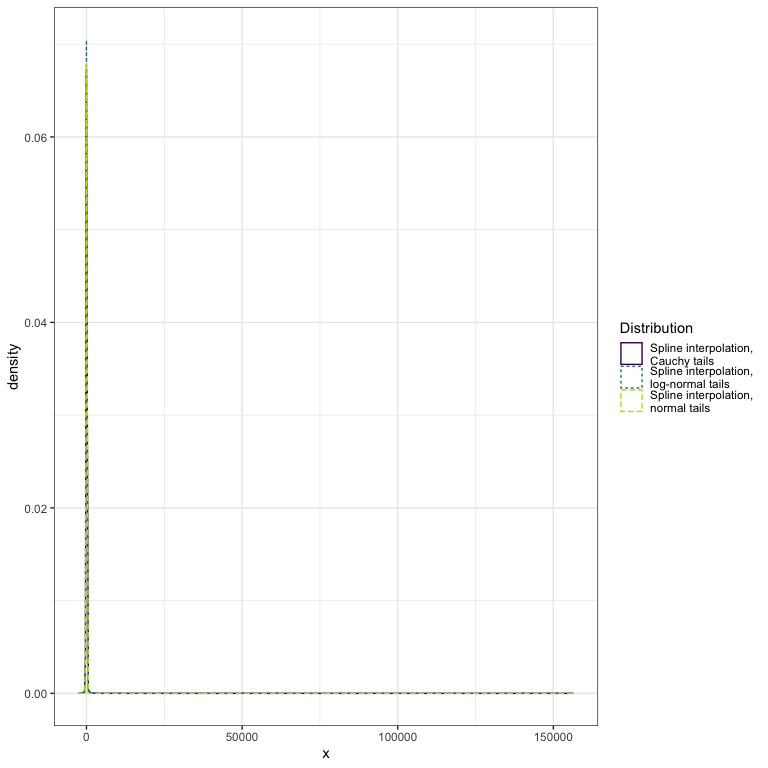

```r
r_normal_approx <- make_r_fn(ps = quantile_probs,
                             qs = q_lognormal,
                             tail_dist = "norm")
r_lognormal_approx <- make_r_fn(ps = quantile_probs,
                                qs = q_lognormal,
                                tail_dist = "lnorm")
r_cauchy_approx <- make_r_fn(ps = quantile_probs,
                             qs = q_lognormal,
                             tail_dist = "cauchy")

normal_approx_sample <- r_normal_approx(n=10000)
lognormal_approx_sample <- r_lognormal_approx(n=10000)
cauchy_approx_sample <- r_cauchy_approx(n=10000)

bind_rows(
    data.frame(x=normal_approx_sample, dist = "Spline interpolation,\nnormal tails"),
    data.frame(x=lognormal_approx_sample, dist = "Spline interpolation,\nlog-normal tails"),
    data.frame(x=cauchy_approx_sample, dist = "Spline interpolation,\nCauchy tails")
) %>%
    ggplot() +
        geom_density(mapping = aes(x = x, color = dist, linetype = dist)) +
        scale_color_viridis_d(
            "Distribution",
            end = 0.9
        ) +
        scale_linetype_discrete("Distribution") +
        theme_bw()
```

The heavy tails of the Cauchy distribution dominate the display. Here we restrict the range of the horizontal axis:

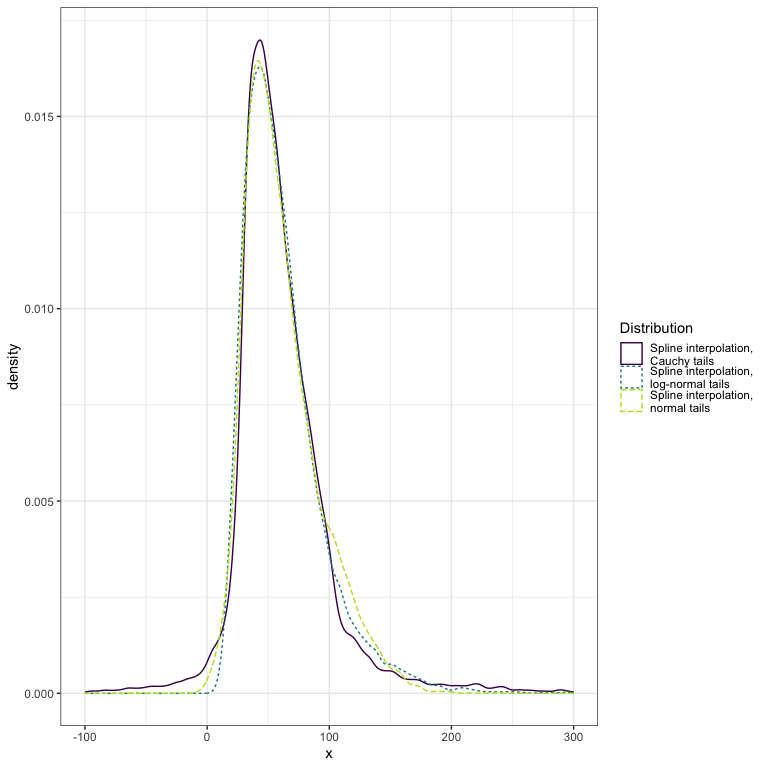

```r
bind_rows(
    data.frame(x=normal_approx_sample, dist = "Spline interpolation,\nnormal tails"),
    data.frame(x=lognormal_approx_sample, dist = "Spline interpolation,\nlog-normal tails"),
    data.frame(x=cauchy_approx_sample, dist = "Spline interpolation,\nCauchy tails")
) %>%
    ggplot() +
        geom_density(mapping = aes(x = x, color = dist, linetype = dist)) +
        scale_color_viridis_d(
            "Distribution",
            end = 0.9
        ) +
        scale_linetype_discrete("Distribution") +
        xlim(-100, 300) +
        theme_bw()
```

Finally, we display quantile function estimates:

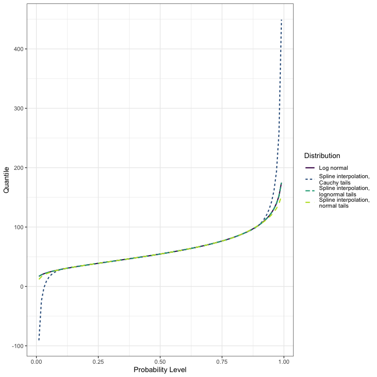

```r
ps <- seq(from = 0.01, to = 0.99, by = 0.01)

q_normal_approx <- make_q_fn(ps = quantile_probs,
                             qs = q_lognormal,
                             tail_dist = "norm")
q_lognormal_approx <- make_q_fn(ps = quantile_probs,
                                qs = q_lognormal,
                                tail_dist = "lnorm")
q_cauchy_approx <- make_q_fn(ps = quantile_probs,
                             qs = q_lognormal,
                             tail_dist = "cauchy")

quantiles_lognormal <- qlnorm(ps, meanlog = meanlog, sdlog = sdlog)
quantiles_normal_approx <- q_normal_approx(ps)
quantiles_lognormal_approx <- q_lognormal_approx(ps)
quantiles_cauchy_approx <- q_cauchy_approx(ps)


dplyr::bind_rows(
    data.frame(
        x = ps,
        y = quantiles_lognormal,
        dist = "Log normal"
    ),
    data.frame(
        x = ps,
        y = quantiles_normal_approx,
        dist = "Spline interpolation,\nnormal tails"
    ),
    data.frame(
        x = ps,
        y = quantiles_lognormal_approx,
        dist = "Spline interpolation,\nlognormal tails"
    ),
    data.frame(
        x = ps,
        y = quantiles_cauchy_approx,
        dist = "Spline interpolation,\nCauchy tails"
    )
) %>%
    ggplot() +
        geom_line(
            mapping = aes(x = x, y = y, color = dist, linetype = dist),
            size = 0.8) +
        scale_color_viridis_d(
            "Distribution",
            end = 0.9
        ) +
        scale_linetype_discrete("Distribution") +
        ylab("Quantile") +
        xlab("Probability Level") +
        theme_bw()
```

## Example 2: lognormal tails with a point mass at 0

A lognormal distribution specifies that $P(X \leq 0) = 0$, i.e., the random variable will always non-negative values. If a lognormal tail distribution is used, e.g. to ensure that the distribution’s support is non-negative and to capture a long right tail, the package inserts a point mass at 0 if any provided quantiles are 0. We illustrate this behavior in this example.

```r
# mixture of a LogNormal(4, 0.5) distribution with weight 0.8 and
# a point mass at 0 with weight 0.2

# probabilities and quantiles for the lognormal component
lnorm_ps <- seq(from = 0.1, to = 0.9, by = 0.1)
lnorm_qs <- qlnorm(lnorm_ps, meanlog = 4.0, sdlog = 0.5)
adj_lnorm_ps <- 0.2 + lnorm_ps * 0.8

# quantile at 0 with probability 0.2 for the point mass at 0
point_p <- 0.2
point_q <- 0.0

ps <- c(point_p, adj_lnorm_ps)
qs <- c(point_q, lnorm_qs)
```

Note that the cdf estimate is zero below 0, jumps to 0.2 at 0, and is continuous thereafter.

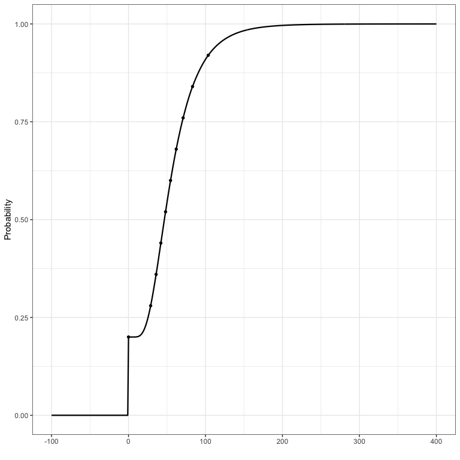

```r
x <- seq(from = -100.0, to = 400.0, length = 501)

p_lognormal_approx <- make_p_fn(ps = ps,
                                qs = qs,
                                tail_dist = "lnorm")
cdf_lognormal_approx <- p_lognormal_approx(x)

data.frame(
    x = x,
    y = cdf_lognormal_approx
) %>%
    ggplot() +
        geom_line(
            mapping = aes(x = x, y = y),
            size = 0.8) +
        geom_point(
            data = data.frame(q = qs, p = ps),
            mapping = aes(x = q, y = p),
            size = 1.2
        ) +
        ylim(0, 1) +
        ylab("Probability") +
        xlab("") +
        theme_bw()
```

As expected, the quantile function inverts the cdf.

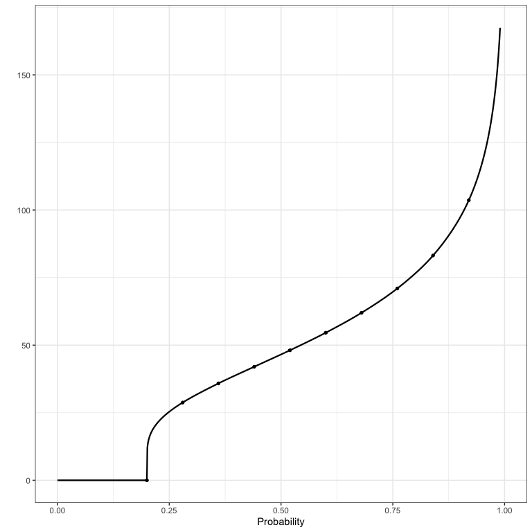

```r
plot_ps <- seq(from = 0.00, to = 0.99, by = 0.001)

q_lognormal_approx <- make_q_fn(ps = ps,
                                qs = qs,
                                tail_dist = "lnorm")
qf_lognormal_approx <- q_lognormal_approx(plot_ps)

data.frame(
    x = plot_ps,
    y = qf_lognormal_approx
) %>%
    ggplot() +
        geom_line(
            mapping = aes(x = x, y = y),
            size = 0.8) +
        geom_point(
            data = data.frame(q = ps, p = qs),
            mapping = aes(x = q, y = p),
            size = 1.2
        ) +
        xlim(0, 1) +
        xlab("Probability") +
        ylab("") +
        theme_bw()
```

We can verify this by plotting the quantile function estimate with inverted axes on the same display as the cdf estimate:

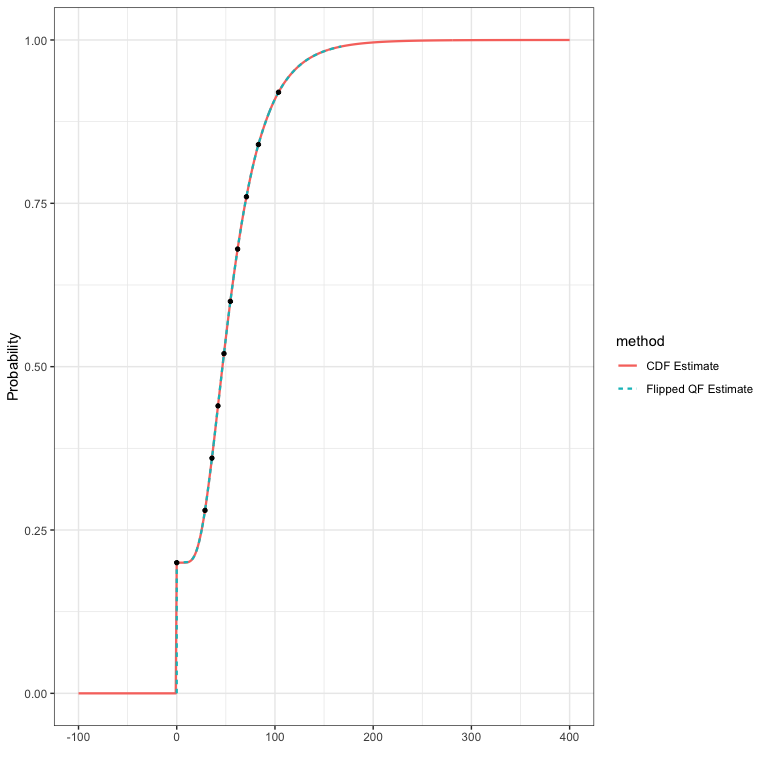

```r
dplyr::bind_rows(
    data.frame(
        x = x,
        y = cdf_lognormal_approx,
        method = "CDF Estimate"
    ),
    data.frame(
        x = qf_lognormal_approx,
        y = plot_ps,
        method = "Flipped QF Estimate"
    )
) %>%
    ggplot() +
        geom_line(
            mapping = aes(x = x, y = y, color = method, linetype = method),
            size = 0.8) +
        geom_point(
            data = data.frame(q = qs, p = ps),
            mapping = aes(x = q, y = p),
            size = 1.2
        ) +
        ylim(0, 1) +
        ylab("Probability") +
        xlab("") +
        theme_bw()
```

Samples from this distribution estimate will include a concentration of values at 0:

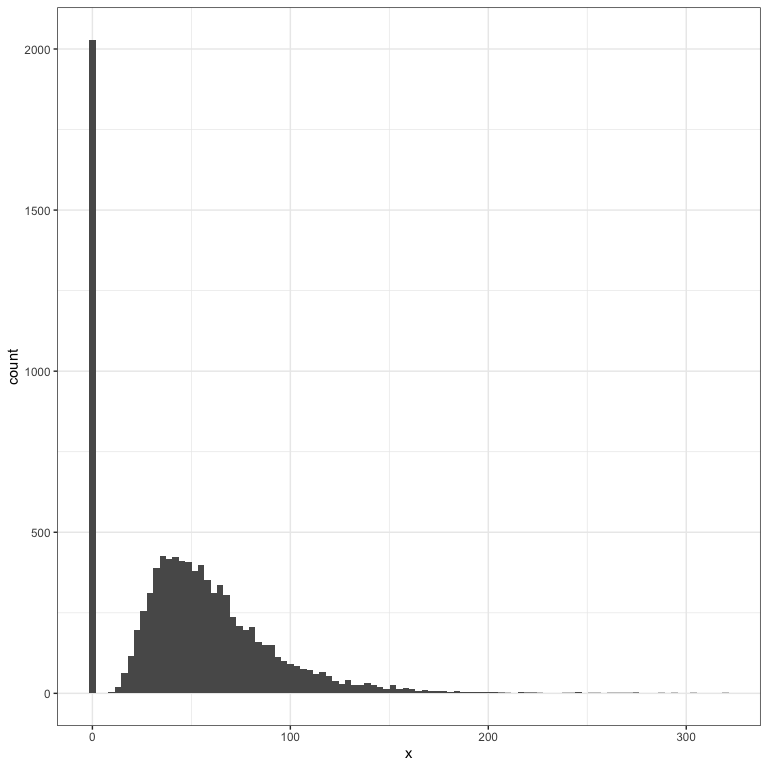

```r
r_fn <- make_r_fn(ps = ps, qs = qs, tail_dist = "lnorm")

sampled_values_df <- data.frame(x = r_fn(10000))

ggplot(sampled_values_df) +
    geom_histogram(mapping = aes(x = x), bins = 100) +
    theme_bw()
```

```r
mean(sampled_values_df$x == 0)
```

```
#> [1] 0.2028
```

Because the distribution has a discrete component, we cannot produce a density estimate:

```r
d_fn_lnorm <- make_d_fn(ps = ps, qs = qs, tail_dist = "lnorm")
```

```
#> Error in make_d_fn(ps = ps, qs = qs, tail_dist = "lnorm"): make_d_fn requires the distribution to be continuous, but a discrete component was detected
```

Note that we do not get an error when estimating the density with a normal tail distribution, because in this case we are not forced to assume that there is a point mass at 0:

```r
d_fn_norm <- make_d_fn(ps = ps, qs = qs, tail_dist = "norm")
```

## Example 3: duplicated quantiles on the interior

When quantile values are the same at multiple probability levels, the distribution assigns non-zero probability to that value, corresponding to a “step” or “jump” in the cumulative distribution function. Again, we note that in this case, `make_d_fn` will throw an error because a continuous density does not exist. We illustrate the behavior of the estimates provided by `make_p_fn` and `make_q_fn` in the presence of repeated quantiles in this and the following example.

```r
quantile_probs <- seq(from = 0.1, to = 0.9, by = 0.1)
quantile_values <- c(1.0, 2.0, 3.0, 3.0, 3.0, 3.0, 3.0, 8.0, 9.0)

d_normal_approx <- make_d_fn(ps = quantile_probs,
                             qs = quantile_values,
                             tail_dist = "norm")
```

```
#> Error in make_d_fn(ps = quantile_probs, qs = quantile_values, tail_dist = "norm"): make_d_fn requires the distribution to be continuous, but a discrete component was detected
```

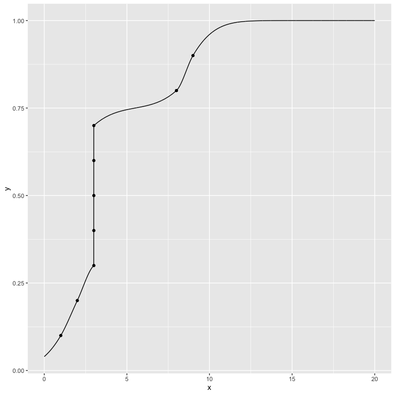

```r
p_normal_approx <- make_p_fn(ps = quantile_probs,
                             qs = quantile_values,
                             tail_dist = "norm")
q_normal_approx <- make_q_fn(ps = quantile_probs,
                             qs = quantile_values,
                             tail_dist = "norm")
r_normal_approx <- make_r_fn(ps = quantile_probs,
                             qs = quantile_values,
                             tail_dist = "norm")

x <- seq(from = 0.0, to = 20.0, length = 5001)
cdf_normal_approx <- p_normal_approx(x)
ggplot() +
  geom_line(data = data.frame(x = x, y = cdf_normal_approx),
            mapping = aes(x = x, y = y)) +
  geom_point(data = data.frame(x = quantile_values, y = quantile_probs),
             mapping = aes(x = x, y = y))
```

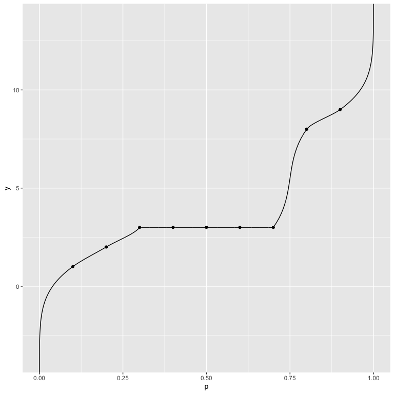

```r
ps <- seq(from = 0.0, to = 1.0, length = 5001)
qf_normal_approx <- q_normal_approx(ps)
ggplot() +
  geom_line(data = data.frame(p = ps, y = qf_normal_approx),
            mapping = aes(x = p, y = y)) +
  geom_point(data = data.frame(x = quantile_probs, y = quantile_values),
             mapping = aes(x = x, y = y))
```

```r
samples_normal_approx <- r_normal_approx(n = 10000)
mean(samples_normal_approx == 3.0)
```

```
#> [1] 0.4019
```

We confirm here that the estimated CDF and QF are indeed inverses to a high degree of numerical precision in regions where the distribution is continuous:

```r
ps <- seq(from = 0.0, to = 1.0, length = 101)
out_ps <- p_normal_approx(q_normal_approx(ps))
out_ps
```

```
#>   [1] 0.00 0.01 0.02 0.03 0.04 0.05 0.06 0.07 0.08 0.09 0.10 0.11 0.12 0.13 0.14
#>  [16] 0.15 0.16 0.17 0.18 0.19 0.20 0.21 0.22 0.23 0.24 0.25 0.26 0.27 0.28 0.29
#>  [31] 0.30 0.70 0.70 0.70 0.70 0.70 0.70 0.70 0.70 0.70 0.70 0.70 0.70 0.70 0.70
#>  [46] 0.70 0.70 0.70 0.70 0.70 0.70 0.70 0.70 0.70 0.70 0.70 0.70 0.70 0.70 0.70
#>  [61] 0.70 0.70 0.70 0.70 0.70 0.70 0.70 0.70 0.70 0.70 0.70 0.71 0.72 0.73 0.74
#>  [76] 0.75 0.76 0.77 0.78 0.79 0.80 0.81 0.82 0.83 0.84 0.85 0.86 0.87 0.88 0.89
#>  [91] 0.90 0.91 0.92 0.93 0.94 0.95 0.96 0.97 0.98 0.99 1.00
```

```r
ps[(ps < 0.3) | (ps > 0.7)] - out_ps[(ps < 0.3) | (ps > 0.7)]
```

```
#>  [1]  0.000000e+00 -1.561251e-17 -3.469447e-18 -1.040834e-17  0.000000e+00
#>  [6] -2.775558e-17  2.775558e-17  0.000000e+00  0.000000e+00  0.000000e+00
#> [11]  0.000000e+00  0.000000e+00  0.000000e+00  0.000000e+00  0.000000e+00
#> [16]  0.000000e+00  0.000000e+00  0.000000e+00  0.000000e+00 -2.775558e-17
#> [21]  0.000000e+00  0.000000e+00  2.775558e-17  0.000000e+00  0.000000e+00
#> [26]  0.000000e+00  5.551115e-17  0.000000e+00  0.000000e+00  0.000000e+00
#> [31]  0.000000e+00  0.000000e+00  0.000000e+00  0.000000e+00  0.000000e+00
#> [36]  0.000000e+00  0.000000e+00  0.000000e+00  0.000000e+00  0.000000e+00
#> [41]  0.000000e+00  0.000000e+00  0.000000e+00  0.000000e+00  1.110223e-16
#> [46]  0.000000e+00  0.000000e+00 -1.110223e-16  0.000000e+00 -1.110223e-16
#> [51]  0.000000e+00  0.000000e+00  1.110223e-16  0.000000e+00  0.000000e+00
#> [56]  0.000000e+00  0.000000e+00  1.110223e-16  0.000000e+00  0.000000e+00
#> [61]  0.000000e+00
```

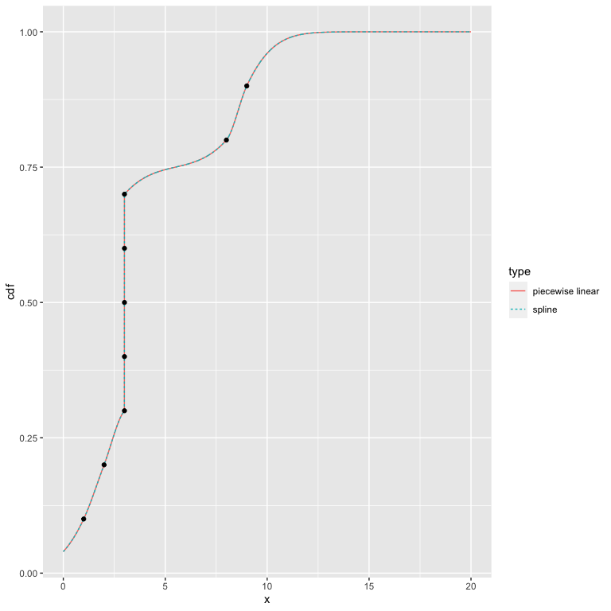

```r
p_normal_approx_spline <- make_p_fn(ps = quantile_probs,
                             qs = quantile_values,
                             tail_dist = "norm",
                             interior_args = list(n_grid = NULL))
q_normal_approx_spline <- make_q_fn(ps = quantile_probs,
                             qs = quantile_values,
                             tail_dist = "norm",
                             interior_args = list(n_grid = NULL))

x <- seq(from = 0.0, to = 20.0, length = 5001)
plot_df <- rbind(
    data.frame(
        x = x,
        cdf = p_normal_approx(x),
        type = "piecewise linear"
    ),
    data.frame(
        x = x,
        cdf = p_normal_approx_spline(x),
        type = "spline"
    )
)
ggplot() +
  geom_line(data = plot_df,
            mapping = aes(x = x, y = cdf, color = type, linetype = type)) +
  geom_point(data = data.frame(x = quantile_values, y = quantile_probs),
             mapping = aes(x = x, y = y))
```

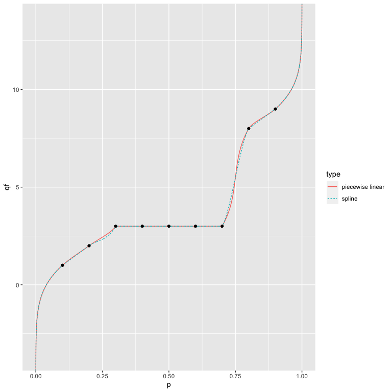

```r
ps <- seq(from = 0.0, to = 1.0, length = 5001)
plot_df <- rbind(
    data.frame(
        p = ps,
        qf = q_normal_approx(ps),
        type = "piecewise linear"
    ),
    data.frame(
        p = ps,
        qf = q_normal_approx_spline(ps),
        type = "spline"
    )
)
ggplot() +
    geom_line(data = plot_df,
              mapping = aes(x = p, y = qf, color = type, linetype = type)) +
    geom_point(data = data.frame(x = quantile_probs, y = quantile_values),
               mapping = aes(x = x, y = y))
```

We therefore recommend using the piecewise linear representation when using a quantile function or generating random deviates, which uses the quantile function in the background.

## Example 4: duplicated quantiles in the tails

Our final example illustrates the behavior when there are duplicated quantiles at the edges. In these cases, we ignore the specified `tail_dist`, and assume that the point mass at the edge contains all of the tail probability.

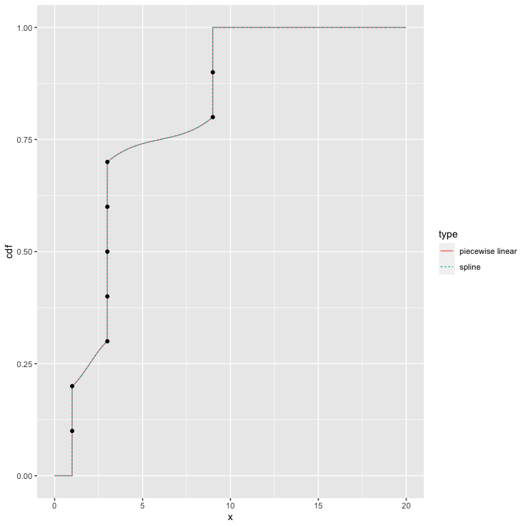

```r
quantile_probs <- seq(from = 0.1, to = 0.9, by = 0.1)
quantile_values <- c(1.0, 1.0, 3.0, 3.0, 3.0, 3.0, 3.0, 9.0, 9.0)

p_normal_approx <- make_p_fn(ps = quantile_probs,
                             qs = quantile_values,
                             tail_dist = "norm")
p_normal_approx_lin <- make_p_fn(ps = quantile_probs,
                             qs = quantile_values,
                             tail_dist = "norm",
                             interior_args = list(n_grid = 20))
q_normal_approx <- make_q_fn(ps = quantile_probs,
                             qs = quantile_values,
                             tail_dist = "norm")
q_normal_approx_lin <- make_q_fn(ps = quantile_probs,
                             qs = quantile_values,
                             tail_dist = "norm",
                             interior_args = list(n_grid = 20))

x <- seq(from = 0.0, to = 20.0, length = 5001)
plot_df <- rbind(
    data.frame(
        x = x,
        cdf = p_normal_approx(x),
        type = "spline"
    ),
    data.frame(
        x = x,
        cdf = p_normal_approx_lin(x),
        type = "piecewise linear"
    )
)
ggplot() +
  geom_line(data = plot_df,
            mapping = aes(x = x, y = cdf, color = type, linetype = type)) +
  geom_point(data = data.frame(x = quantile_values, y = quantile_probs),
             mapping = aes(x = x, y = y))
```

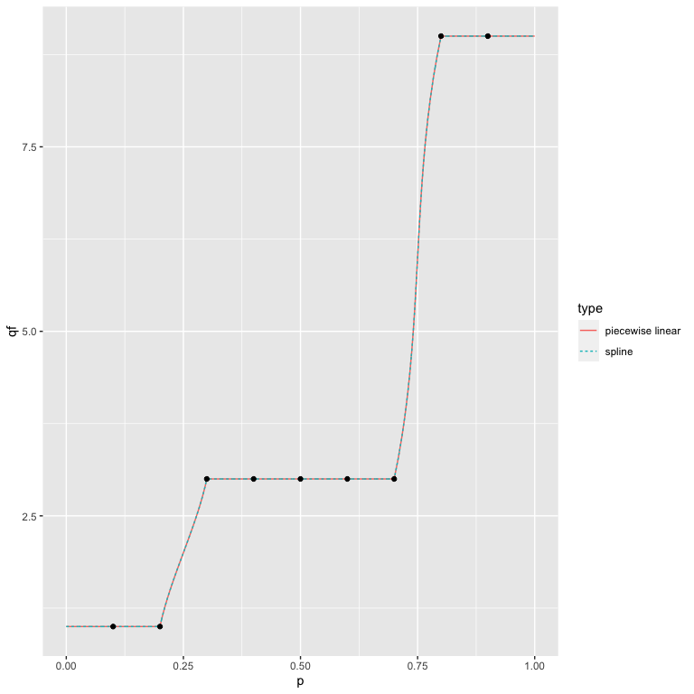

```r
ps <- seq(from = 0.0, to = 1.0, length = 5001)
plot_df <- rbind(
    data.frame(
        p = ps,
        qf = q_normal_approx(ps),
        type = "spline"
    ),
    data.frame(
        p = ps,
        qf = q_normal_approx_lin(ps),
        type = "piecewise linear"
    )
)
ggplot() +
    geom_line(data = plot_df,
              mapping = aes(x = p, y = qf, color = type, linetype = type)) +
    geom_point(data = data.frame(x = quantile_probs, y = quantile_values),
               mapping = aes(x = x, y = y))
```